# PD 1

Piotr Piątyszek

# 1) dataMaid: Your Assistant for Documenting Supervised Data Quality Screening in R

From the article’s abstract, where `dataMaid` package is described as implementing *“an extensive and customizable suite of quality assessment aids that can be applied to a dataset in order to identify potential problems in its variables. The results are presented in an auto-generated, non-technical, stand-alone overview document intended to be perused by an investigator with an understanding of the variables in the data, but not necessarily knowledge of R”* we can find out what the package is for.

[the article page link](https://www.jstatsoft.org/index.php/jss/article/view/v090i06)

[CRAN link](https://cran.r-project.org/web/packages/dataMaid/index.html)

Firstly, the installation - it went smoothly and fast.

```r
install.packages('dataMaid')
```

#### Creating a data overview report

*“The `makeDataReport()` function is the primary workhorse of dataMaid and it is the only function needed to generate a data report using the standard battery of tests. The data report itself is an overview document, intended for reading by humans, in either PDF, HTML or Word (.docx) format”*

There was an appendix provided as an example of a data report in PDF format, produced by calling `makeDataReport()` on the dataset `toyData` available in `dataMaid`.

```r
library("dataMaid")
data("toyData", package = "dataMaid")
toyData
```

```
## # A tibble: 15 x 6
##    pill  events region  change id    spotifysong
##    <fct>  <dbl> <fct>    <dbl> <fct> <fct>
##  1 red        1 "a"     -0.626 1     Irrelevant
##  2 red        1 "a"      0.184 2     Irrelevant
##  3 red        1 "a"     -0.836 3     Irrelevant
##  4 red        2 "a"      1.60  4     Irrelevant
##  5 red        2 "a"      0.330 5     Irrelevant
##  6 red        6 "b"     -0.820 6     Irrelevant
##  7 red        6 "b"      0.487 7     Irrelevant
##  8 red        6 "b"      0.738 8     Irrelevant
##  9 red      999 "c"      0.576 9     Irrelevant
## 10 red       NA "c"     -0.305 10    Irrelevant
## 11 blue       4 "c"      1.51  11    Irrelevant
## 12 blue      82 "."      0.390 12    Irrelevant
## 13 blue      NA " "     -0.621 13    Irrelevant
## 14 <NA>     NaN "other" -2.21  14    Irrelevant
## 15 <NA>       5 "OTHER"  1.12  15    Irrelevant
```

The dataset was loaded successfully.

```r
makeDataReport(toyData)
```

An R markdown file and a rendered PDF, Word or HTML overview document are produced, saved to the working directory and opened for immediate inspection. It all worked as descibed.

```r
# html output
makeDataReport(toyData, output = "html", onlyProblematic = TRUE, maxProbVals = 2, replace = TRUE)

# html - options set not to render nor open
makeDataReport(toyData, output = "html", render = FALSE, openResult = FALSE, replace = TRUE)
```

The html output also worked correctly, so by far this article’s reproducibility is great.

Now, let’s see how some helper functions work:

```r
allSummaryFunctions()
```

| name | description | classes |
| --- | --- | --- |
| centralValue | Compute median for numeric variables, mode for categorical variables | character, Date, factor, integer, labelled, haven_labelled, logical, numeric |
| countMissing | Compute proportion of missing observations | character, Date, factor, integer, labelled, haven_labelled, logical, numeric |
| minMax | Find minimum and maximum values | integer, numeric, Date |
| quartiles | Compute 1st and 3rd quartiles | Date, integer, numeric |
| refCat | Find reference level | factor |
| uniqueValues | Count number of unique values | character, Date, factor, integer, labelled, haven_labelled, logical, numeric |
| variableType | Data class of variable | character, Date, factor, integer, labelled, haven_labelled, logical, numeric |

```r
setSummaries()
```

```
## $character
## [1] "variableType" "countMissing" "uniqueValues" "centralValue"
##
## $factor
## [1] "variableType" "countMissing" "uniqueValues" "centralValue" "refCat"
##
## $labelled
## [1] "variableType" "countMissing" "uniqueValues" "centralValue"
##
## $haven_labelled
## [1] "variableType" "countMissing" "uniqueValues" "centralValue"
##
## $numeric
## [1] "variableType" "countMissing" "uniqueValues" "centralValue" "quartiles"
## [6] "minMax"
##
## $integer
## [1] "variableType" "countMissing" "uniqueValues" "centralValue" "quartiles"
## [6] "minMax"
##
## $logical
## [1] "variableType" "countMissing" "uniqueValues" "centralValue"
##
## $Date
## [1] "variableType" "countMissing" "uniqueValues" "centralValue" "minMax"
## [6] "quartiles"
```

```r
defaultCharacterSummaries()
```

```
## [1] "variableType" "countMissing" "uniqueValues" "centralValue"
```

```r
defaultFactorChecks()
```

```
## [1] "identifyMissing"    "identifyWhitespace" "identifyLoners"
## [4] "identifyCaseIssues" "identifyNums"
```

The results are exactly as expected.

#### Data cleaning by hand: An example

```r
check(toyData$events)
```

```
## $identifyMissing
## The following suspected missing value codes enter as regular values: 999, NaN.
## $identifyOutliers
## Note that the following possible outlier values were detected: 82, 999.
```

```r
check(toyData$events, checks = setChecks(numeric = "identifyMissing"))
```

```
## $identifyMissing
## The following suspected missing value codes enter as regular values: 999, NaN.
```

```r
identifyMissing(toyData$events)
```

```
## The following suspected missing value codes enter as regular values: 999, NaN.
```

```r
missEvents <- identifyMissing(toyData$events)
str(missEvents)
```

```
## List of 3
##  $ problem      : logi TRUE
##  $ message      : chr "The following suspected missing value codes enter as regular values: \\\"999\\\", \\\"NaN\\\"."
##  $ problemValues: num [1:2] 999 NaN
##  - attr(*, "class")= chr "checkResult"
```

```r
toyData$events[toyData$events %in% missEvents$problemValues] <- NA
identifyMissing(toyData$events)
```

```
## No problems found.
```

Let’s check `visualize{)` and `summarize()` functions’ results`

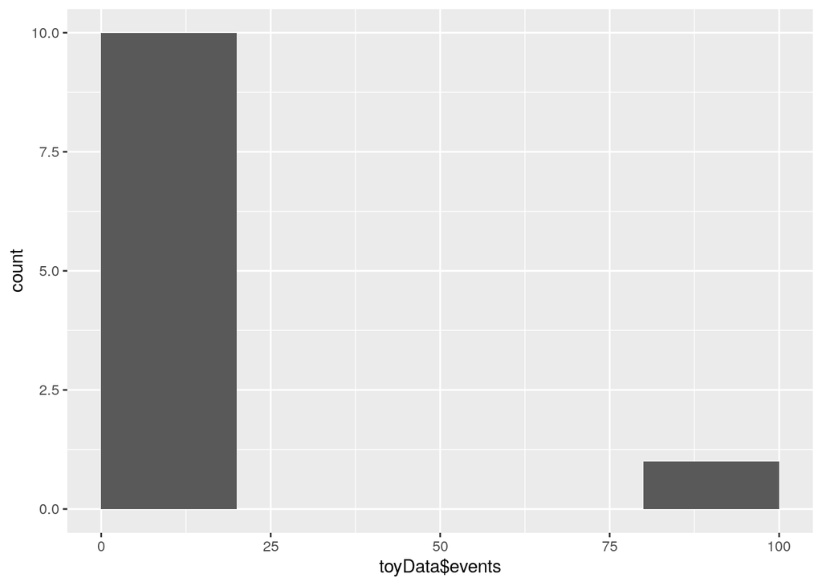

```r
visualize(toyData$events)
```

```r
summarize(toyData$events)
```

```
## $variableType
## Variable type: numeric
## $countMissing
## Number of missing obs.: 4 (26.67 %)
## $uniqueValues
## Number of unique values: 6
## $centralValue
## Median: 4
## $quartiles
## 1st and 3rd quartiles: 1.5; 6
## $minMax
## Min. and max.: 1; 82
```

```r
summarize(toyData$events, summaries = setSummaries( numeric = defaultNumericSummaries(remove = c("variableType", "countMissing"))))
```

```
## $uniqueValues
## Number of unique values: 6
## $centralValue
## Median: 4
## $quartiles
## 1st and 3rd quartiles: 1.5; 6
## $minMax
## Min. and max.: 1; 82
```

All results are exactly as expected.

#### A worked example: Dirty presidents

This time the task was to create a report describing the `presidentData` dataset, which is available in dataMaid and use the information from this report to clean up the data.

`presidentData` is a slightly mutilated dataset with information about the 45 first US presidents, but with a few common data issues and a blind passenger.

```r
data("presidentData", package = "dataMaid")
head(presidentData)

makeDataReport(presidentData, replace = TRUE,
 treatXasY = list("Name" = "character"), checks = setChecks(character =
 defaultCharacterChecks(remove = "identifyLoners")),
 reportTitle = "Dirty president data")
```

PDF output is correct again.

```r
# df modifications
presidentData$lastName[presidentData$lastName == " Truman"] <- "Truman"
presidentData$stateOfBirth[presidentData$stateOfBirth == "New york"] <- "New York"
presidentData$assassinationAttempt <- factor(presidentData$assassinationAttempt)
presidentData$ageAtInauguration <- as.numeric(presidentData$ageAtInauguration)
presidentData$ageAtInauguration <- as.numeric(as.character(presidentData$ageAtInauguration))
presidentData$lastName[presidentData$firstName == "."]
```

```
## [1] "Trump"
```

```r
presidentData$firstName[presidentData$firstName == "."] <- "Donald"

# Now, we have the outlier birthday stored and can use it
# to select and print the appropriate observation in the dataset:
birthdayOutlierVal <- identifyOutliers(presidentData$birthday)$problemValues
presidentData[presidentData$birthday == birthdayOutlierVal, ]
```

```
##       lastName firstName orderOfPresidency   birthday stateOfBirth
## 46 Arathornson   Aragorn                 0 1300-03-01       Gondor
##    assassinationAttempt  sex ethnicity presidencyYears ageAtInauguration
## 46                    1 Male Caucasian              NA                87
##    favoriteNumber
## 46           8+0i
```

```r
presidentData <-  presidentData[presidentData$birthday != birthdayOutlierVal, ]
summarize(presidentData$presidencyYears)
```

```
## $variableType
## Variable type: numeric
## $countMissing
## Number of missing obs.: 1 (2.22 %)
## $uniqueValues
## Number of unique values: 10
## $centralValue
## Median: 4
## $quartiles
## 1st and 3rd quartiles: 3.75; 8
## $minMax
## Min. and max.: 0; Inf
```

```r
presidentData[is.na(presidentData$presidencyYears) |
 presidentData$presidencyYears %in%
 identifyOutliers(presidentData$presidencyYears)$problemValues,
 c("firstName", "lastName", "presidencyYears")]
```

```
##    firstName lastName presidencyYears
## 9    William Harrison               0
## 12   Zachary   Taylor               1
## 13   Millard Fillmore               2
## 20     James Garfield               0
## 29    Warren  Harding               2
## 35      John  Kennedy               2
## 38    Gerald     Ford               2
## 44    Barack    Obama             Inf
## 45    Donald    Trump              NA
```

```r
presidentData$presidencyYears[presidentData$lastName == "Obama"] <- 8
```

```r
makeDataReport(presidentData, vol = "_cleaned",
 treatXasY = list(Name = "character", complex = "numeric"),
 checks = setChecks(character =
 defaultCharacterChecks(remove = "identifyLoners")),
 reportTitle = "Dirty president data - cleaned", replace = TRUE)
```

The last created a new data report stored in the file dataMaid_presidentData_cleaned.pdf

#### Rubbing down data cleaning challenges

```r
makeDataReport(toyData, open = FALSE, quiet = "silent", vol = paste("_", format(Sys.time(), "%m-%d%-%y_%H.%M"), sep = ""))
```

```r
makeDataReport(toyData, onlyProblematic = TRUE, mode = "check", replace = TRUE)
```

Only the checking results were printed, and only for variables where problems were identified.

```r
toyChecks <- check(toyData)
foo <- function(x) { any(sapply(x, function(y) y[["problem"]]))}
sapply(toyChecks, foo)
```

```
##        pill      events      region      change          id spotifysong
##        TRUE        TRUE        TRUE        TRUE        TRUE       FALSE
```

### Verdict

This article’s reproducibility is **very good**.

# 2) clustMixType: User-Friendly Clustering of Mixed-Type Data in R by Gero Szepannek

the R package `clustMixType` which provides an implementation of k-prototypes in R

[the article page link](https://journal.r-project.org/archive/2018/RJ-2018-048/index.html)

The installation went smoothly and fast.

```r
install.packages("clustMixType")

# also will be needed:
install.packages("wesanderson")
```

We tried to reproduce the output od the example from the article:

```r
# generate toy data with factors and numerics

n   <- 100
prb <- 0.9
muk <- 1.5
clusid <- rep(1:4, each = n)

x1 <- sample(c("A","B"), 2*n, replace = TRUE, prob = c(prb, 1-prb))
x1 <- c(x1, sample(c("A","B"), 2*n, replace = TRUE, prob = c(1-prb, prb)))
x1 <- as.factor(x1)

x2 <- sample(c("A","B"), 2*n, replace = TRUE, prob = c(prb, 1-prb))
x2 <- c(x2, sample(c("A","B"), 2*n, replace = TRUE, prob = c(1-prb, prb)))
x2 <- as.factor(x2)

x3 <- c(rnorm(n, mean = -muk), rnorm(n, mean = muk), rnorm(n, mean = -muk), rnorm(n, mean = muk))
x4 <- c(rnorm(n, mean = -muk), rnorm(n, mean = muk), rnorm(n, mean = -muk), rnorm(n, mean = muk))

x <- data.frame(x1,x2,x3,x4)

library(clustMixType)
kpres <- kproto(x = x, k = 4)
```

```
## # NAs in variables:
## x1 x2 x3 x4
##  0  0  0  0
## 0 observation(s) with NAs.
##
## Estimated lambda: 6.077853
```

```r
kpres # output 1
```

```
## Numeric predictors: 2
## Categorical predictors: 2
## Lambda: 6.077853
##
## Number of Clusters: 4
## Cluster sizes: 83 97 150 70
## Within cluster error: 212.9091 308.9863 760.2351 394.729
##
## Cluster prototypes:
##   x1 x2         x3         x4
## 1  A  A -1.0304112 -0.6089384
## 2  A  A  1.7442534  1.7433394
## 3  B  B  0.4161906  0.3073839
## 4  A  A -1.9280612 -2.2017278
```

```r
summary(kpres) # output 2
```

```
## x1
##
## cluster     A     B
##       1 0.892 0.108
##       2 0.845 0.155
##       3 0.020 0.980
##       4 0.686 0.314
##
## -----------------------------------------------------------------
## x2
##
## cluster     A     B
##       1 0.892 0.108
##       2 0.876 0.124
##       3 0.013 0.987
##       4 0.614 0.386
##
## -----------------------------------------------------------------
## x3
##         Min.    1st Qu.     Median       Mean    3rd Qu.     Max.
## 1 -2.9662113 -1.5940350 -1.1506282 -1.0304112 -0.5305305 1.010314
## 2  0.2041482  1.2628517  1.7422658  1.7442534  2.2537808 3.741865
## 3 -3.6605415 -0.8748404  0.6506758  0.4161906  1.7069770 3.358791
## 4 -3.8537606 -2.5941733 -1.8840545 -1.9280612 -1.2380428 0.464068
##
## -----------------------------------------------------------------
## x4
##        Min.    1st Qu.     Median       Mean   3rd Qu.       Max.
## 1 -2.081458 -1.1014963 -0.6741091 -0.6089384 -0.146694  1.4027394
## 2 -0.474957  1.0626429  1.6171026  1.7433394  2.487726  3.9392447
## 3 -3.279484 -0.9076641  0.5664745  0.3073839  1.330083  3.9505743
## 4 -3.938044 -2.6371476 -2.1196724 -2.2017278 -1.751020 -0.8772263
##
## -----------------------------------------------------------------
```

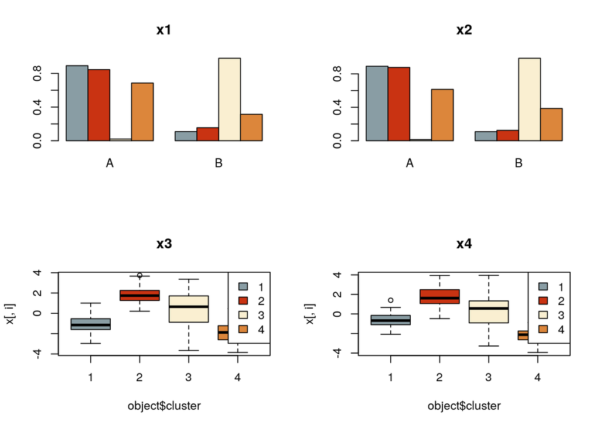

```r
library(wesanderson)
par(mfrow=c(2,2))
clprofiles(kpres, x, col = wes_palette("Royal1", 4, type = "continuous")) # figure 1
```

The resulting output is of the form as it should. It isn’t identic as we used `sample()` function.

```r
Es <- numeric(10)
for(i in 1:10){
kpres <- kproto(x, k = i, nstart = 5)
Es[i] <- kpres$tot.withinss
}
```

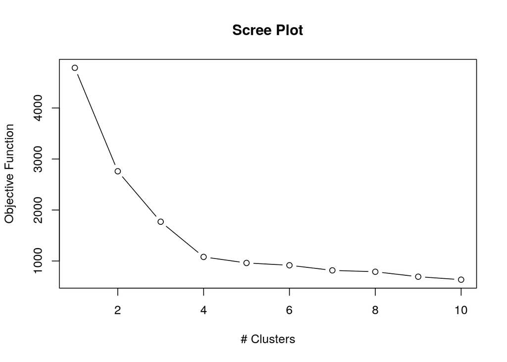

```r
plot(1:10, Es, type = "b", ylab = "Objective Function", xlab = "# Clusters",
main = "Scree Plot") # figure 2
```

### Verdict

This article’s reproducibility is **good**.

# 3) Forecast Combinations in R using the `ForecastComb` Package

This package is to provide researchers and practitioners with a comprehensive implementation of the most common ways in which forecasts can be combined.

[the article page link](https://journal.r-project.org/archive/2018/RJ-2018-052/index.html)

The installation - it lasted a while, but it was ok in the end.

```r
install.packages("ForecastComb")
```

Firstly, we gonna check if a simple simulation example is reproducible:

```r
library(ForecastComb)
actual <- rnorm(100)
forecasts <- matrix(rnorm(1000, 1), 100, 10)
input_data <- foreccomb(actual, forecasts)
# Manual Selection of Trimming Factor:
model1 <- comb_TA(input_data, trim_factor = 0.3)
# Assess accuracy of the combined forecast:
model1$Accuracy_Train
```

```
##                ME     RMSE      MAE      MPE     MAPE         ACF1 Theil's U
## Test set -1.03136 1.559191 1.277492 140.4462 468.6408 -0.007181026  1.645772
```

```r
# Algorithm-Optimized Selection of Trimming Factor:
model2 <- comb_TA(input_data, criterion = "RMSE")
```

```
## Optimization algorithm chooses trim factor for trimmed mean approach...
```

```
## Algorithm finished. Optimized trim factor: 0
```

```r
# Assess accuracy of the combined forecast:
model2$Accuracy_Train
```

```
##                 ME    RMSE      MAE      MPE     MAPE        ACF1 Theil's U
## Test set -1.032352 1.54092 1.262954 95.57198 461.5657 -0.03867842  1.667381
```

There was a misspell ‘model1$AccuracyTrain’ didn’t work at first. After adding the symbol ’_’ it is all good.

#### UK Electricity Supply: An Empirical Example

The ForecastComb package includes the dataset `electricity`, which is a multivariate time series of monthly UK electricity supply (in GWh) from January 2007 to March 2017, and 5 univariate time series forecasts for the same series and period. The observed data series is sourced from the International Energy Agency (IEA, 2017).

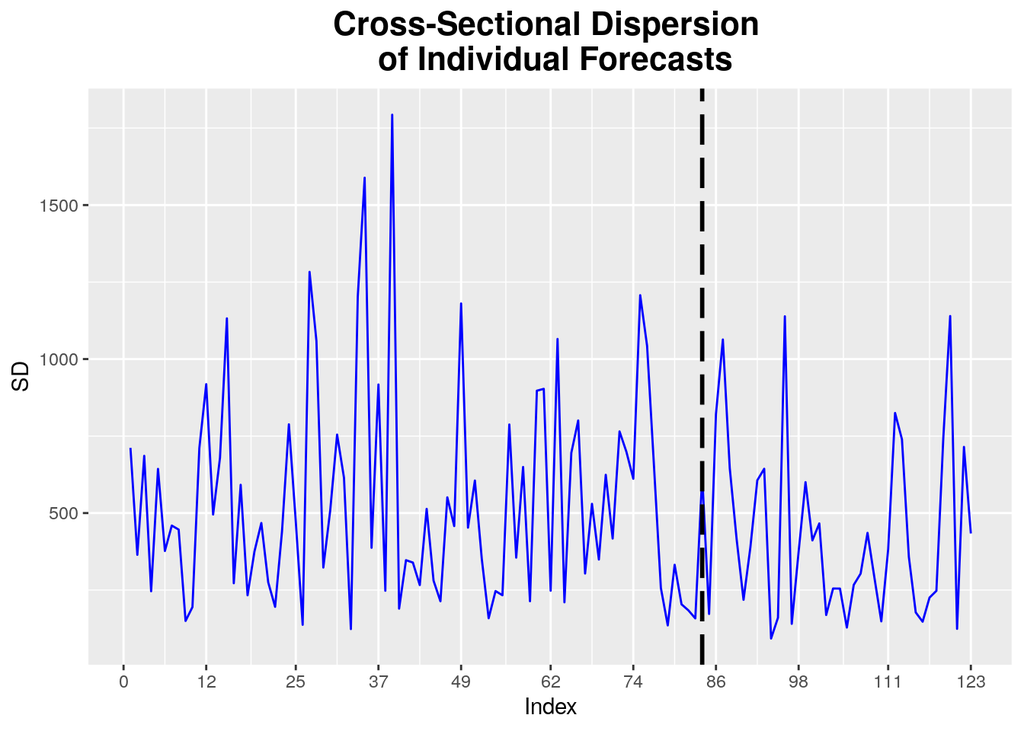

```
## $Dispersion_Measure
## [1] "SD"
##
## $CS_Dispersion
##   [1]  711.63539  364.45474  685.71698  246.22783  643.33761  376.93526
##   [7]  459.40069  446.36638  149.77543  194.79344  710.81992  918.51445
##  [13]  495.34307  679.66623 1132.10945  272.20790  591.71543  233.05312
##  [19]  375.17675  467.74993  275.07800  195.58474  440.11667  788.10232
##  [25]  472.32090  137.26224 1283.05948 1058.50437  323.19790  508.66794
##  [31]  754.72979  614.39896  123.39112 1202.83656 1588.72714  387.26621
##  [37]  917.45954  247.74217 1793.21916  189.71189  347.03255  339.29270
##  [43]  266.18505  513.61795  280.63135  213.70218  551.04994  457.72783
##  [49] 1180.49284  452.65196  605.56940  351.86034  158.48581  246.80788
##  [55]  233.15245  787.48590  355.34600  649.59636  213.79889  897.23645
##  [61]  903.28625  247.94182 1065.27387  210.25059  695.37601  800.63683
##  [67]  303.74303  529.94926  349.09577  624.16289  417.28082  765.02602
##  [73]  698.68891  611.40817 1207.32526 1042.76692  653.12056  257.03512
##  [79]  135.29548  332.09994  203.69894  184.09980  158.05389  621.05344
##  [85]  172.47614  821.79159 1063.44547  645.97355  414.84094  218.24704
##  [91]  389.78235  606.33241  643.74534   92.69277  160.21199 1138.74066
##  [97]  140.34746  374.94560  600.39781  411.34601  466.32876  169.06720
## [103]  254.97982  254.80226  128.32357  266.81963  303.43653  435.68088
## [109]  290.44132  148.40380  382.83324  824.90290  739.43259  357.79253
## [115]  177.41029  147.30153  225.49361  247.52236  742.26077 1139.65772
## [121]  124.09575  714.76935  433.75957
```

```r
 data(electricity)
 train.obs <- electricity[1:84, 6]
 train.pred <- electricity[1:84, 1:5]
 test.obs <- electricity[85:123, 6]
 test.pred <- electricity[85:123, 1:5]
 input_data <- foreccomb(train.obs, train.pred, test.obs, test.pred)

 cs_dispersion(input_data, measure = "SD", plot = TRUE)
```

```r
  ####### ESTIMATION OF STATIC FORECAST COMBINATIONS ########
SA <- comb_SA(input_data)
OLS_static <- comb_OLS(input_data)
EIG1_static <- comb_EIG1(input_data)
EIG4_static <- comb_EIG4(input_data, criterion = "MAE")
 ###### ESTIMATION OF DYNAMIC FORECAST COMBINATIONS
OLS_dyn <- rolling_combine(input_data, "comb_OLS")
EIG1_dyn <- rolling_combine(input_data, "comb_EIG1")
EIG4_dyn <- rolling_combine(input_data, "comb_EIG4", criterion = "MAE")
```

```r
summary(OLS_static)
```

```
##
## Summary of Forecast Combination
## -------------------------------
##
## Method:  Ordinary Least Squares Regression
##
## Individual Forecasts & Combination Weights:
##
##         Combination Weight
## arima           0.02152869
## ets            -0.20646266
## nnet            0.20992792
## dampedt        -1.04349858
## dotm            1.97991049
##
## Intercept (Bias-Correction):  962.3229
##
## Accuracy of Combined Forecast:
##
##                         ME     RMSE      MAE         MPE     MAPE
## Training Set  1.732609e-13 888.1433 697.8645 -0.08262472 2.254470
## Test set     -4.007742e+01 671.5214 536.0331 -0.24705122 1.841961
##
## Additional information can be extracted from the combination object:
## For fitted values (training set):  OLS_static$Fitted
## For forecasts (test set):  OLS_static$Forecasts_Test
## See  str(OLS_static)  for full list.
```

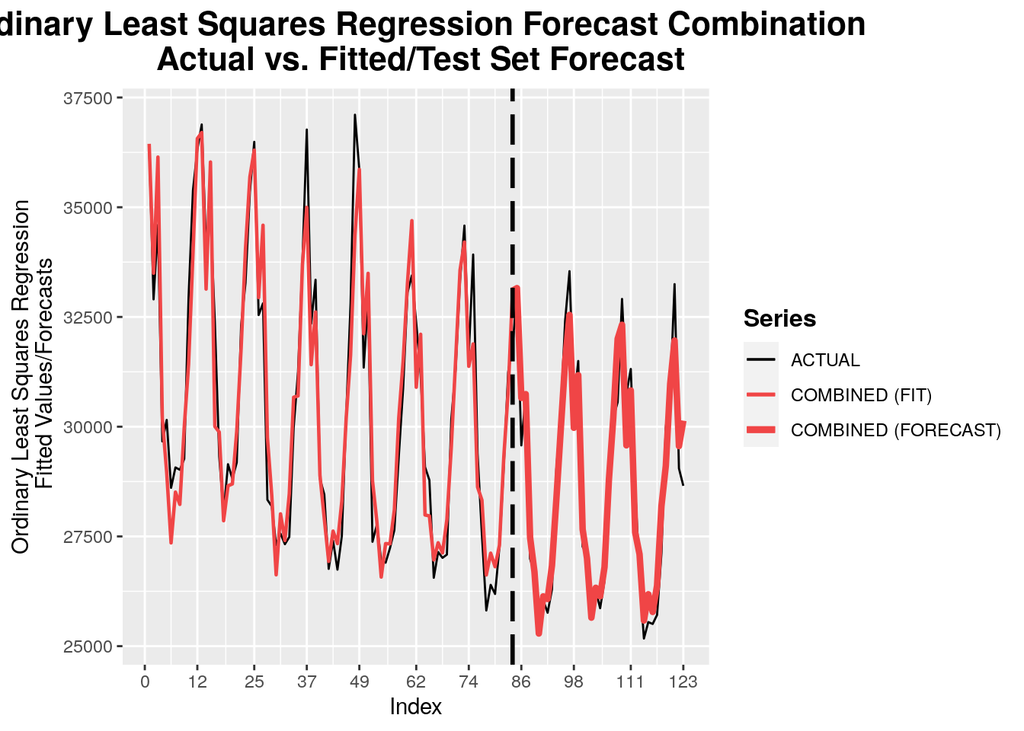

```r
##### ACTUAL VS FITTED PLOT #####
plot(OLS_dyn)
```

```r
 ##### COMBINATION WEIGHTS #####
colMeans(OLS_dyn$Weights)
```

```
## [1]  0.002750948 -0.123811218  0.184846358 -1.098381593  2.001988985
```

The plots and results match the article.

### Verdict

This article’s reproducibility is **very good**.